# act_report

## Report: act_report

Author: Mlungiseleli Notshokovu | Data Analyst

[figure not shown]

## Analyzing and Visualizing Data

After gathering, assessing, cleaning, analyzing the @WeRateDogs twitter data, I derived the following insights and visualizations:

1. What is the top used source to publish tweets?
2. What is the most popular dog breed?
3. What is the most popular dog name?
4. Top 10 highest ratings?
5. Top 10 favourite dog breeds?

The visuals and images help to show the insights in various ways.

## 1. What is the top used source to publish tweets?

The bar plot below shows the top used sources to publish tweets.

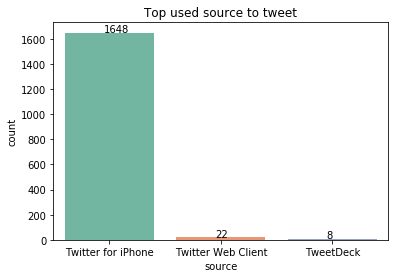

'Twitter for Iphone' is the top used source to publish tweets

## 2. What is the most popular dog breed?

```
Text(0,0.5,'Dog Breed')
```

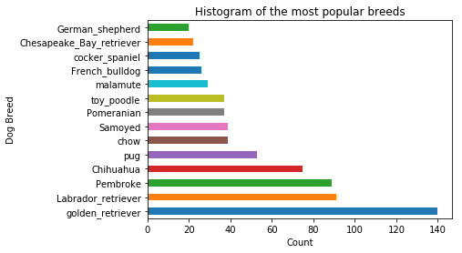

The most dog breed appears to be a Golden Retriever, followed by a Labrador Retriever.

## 3. What is the most popular dog name?

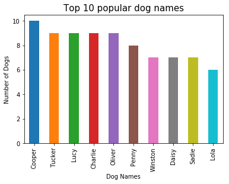

From the above bar plot, 'Copper' appears to be the most popular dog name followed by 'Oliver', 'Charlie', 'Lucy', and 'Tucker'.

## 4. Top 10 highest ratings?

```
450     7.500000
344     3.428571
494     2.700000
1196    2.600000
33      1.400000
358     1.400000
509     1.400000
182     1.400000
263     1.400000
58      1.400000
Name: rating, dtype: float64
```

The above list shows the top 10 highest ratings, with 7.5000 being the highest.

## 5. Top 10 favourite dog breeds?

The list below is the top favourite dog breeds across all the gathered data.

```
dog_breed
golden_retriever      140
Labrador_retriever     91
Pembroke               89
Chihuahua              75
pug                    53
chow                   39
Samoyed                39
toy_poodle             37
Pomeranian             37
malamute               29
Name: favorites, dtype: int64
```

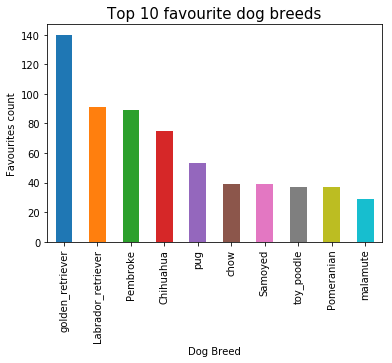

#### Findings summary:

Given more time and resources, I believe more insights could have been derived from this data: the users who publish these tweets, the type of algorithm used to predict dog breeds, etc.